# 04. Analysis of reference free tools

Edoardo Giuili

2025-09-24

## Introduction

### Setting up the environment

First, set up the main directory chaning the paths below

```r
knitr::opts_knit$set(root.dir = '~/OneDrive-UGent/Projects/002_Benchmarking/BenchmarkingAnalysis/')
# Define the directory containing the CSV files
dir_path <- "~/OneDrive-UGent/Projects/002_Benchmarking/BenchmarkingAnalysis/"
```

Import the necessary libraries for the analysis

```r
library(ggpubr)
library(ggplot2)
library(dplyr)
```

Import the useful functions and the metrics

```r
source("R/compute_auc.R")

# RMSE
rmse <- function(actual, predicted) {
  round(sqrt(mean((actual - predicted)^2)),4)
}
# Normalized RMSE (NRMSE)
nrmse <- function(actual, predicted) {
    round(sqrt(mean((actual - predicted))^2)/mean(actual+10e-8),4)
}
# Spearman's rank correlation coefficient (SCC)
scc <- function(actual, predicted) {
  cor(actual, predicted, method = "spearman", use = "pairwise.complete.obs")
}
```

Read the results generated by both reference-free and reference-based tools and concatanate them in a unique dataframe.

```r
bench_refree <- read.csv(paste0(dir_path,"resources/refree_final_dataset.csv"), row.names = 1)
bench_refree <- bench_refree %>% filter(!is.na(bench_refree$predicted_tf))
bench_refbased <- read.csv(paste0(dir_path,"resources/final_benchmarking_dataset.csv"))
bench_refbased <- bench_refbased %>% filter(!is.na(bench_refbased$predicted_tf))
names(bench_refree)[5] <- "dmr_tool"
bench <- rbind(bench_refbased, bench_refree)
```

Select the WGBS and RRBS datasets

```r
in_silico_wgbs <- subset(bench, bench$seq_method == "wgbs")
in_silico_rrbs <- subset(bench, bench$seq_method == "rrbs")
```

## WGBS - ref-based vs ref-free

As always, we will start our comparison analysing the WGBS dataset, to then proceed with the RRBS dataset. We will focus this analysis on the RMSE, since it gives an estimation of the accuracy of the tools in predicting the tumoral fraction.

```r
# Compute the RMSE and add a column specifying whether the tool is ref-free or ref-based
rmse_wgbs <- in_silico_wgbs %>%
  filter(expected_tf != 0) %>%
  group_by(deconv_tool, dmr_tool, seq_depth, tumor_type, expected_tf) %>%
  mutate(RMSE = rmse(expected_tf, predicted_tf)) %>%
  ungroup() %>%
  group_by(seq_depth, tumor_type, expected_tf) %>%
  mutate(
    RMSE_min = min(RMSE),
    RMSE_max = max(RMSE),
    RMSE_minmax = (RMSE - RMSE_min) / (RMSE_max - RMSE_min)
  ) %>%
  group_by(deconv_tool, seq_depth, tumor_type) %>%
  summarise(RMSE = 1-mean(RMSE_minmax), .groups = "drop") %>%
  mutate(RefType = ifelse(deconv_tool %in% c("PRMeth_RF","MeDeCom"), "Reference-free", "Reference-based"))
```

We can now plot the RMSE distribution per deconvolution tool using boxplots. We will color the boxplots based on the RefType column.

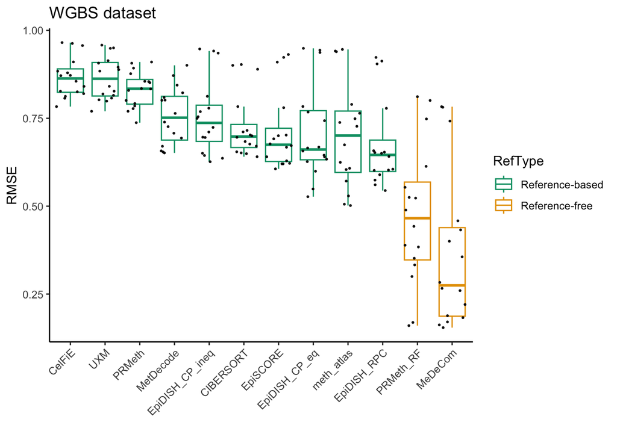

```r
# Rank the tools by mean RMSE
mean_rank <- rmse_wgbs %>%
              group_by(deconv_tool) %>%
              summarise(Mean = mean(RMSE)) %>%
              arrange(desc(Mean))
plot_data <- rmse_wgbs %>%
      mutate(deconv_tool = factor(deconv_tool, levels = mean_rank$deconv_tool))

# Plot the data
p <- plot_data %>%
        ggplot(aes(x = deconv_tool, y = RMSE, color = RefType)) +
        geom_boxplot(alpha = 0.8, outliers = F) +
        geom_jitter(color="black", size=0.4, alpha=0.9) +
        labs(
          title = "WGBS dataset",
          x = "",
          y = "RMSE"
        ) +
        theme_classic() +
        theme(
          axis.text.x = element_text(angle = 45, hjust = 1)
        ) +
        scale_color_manual(values = c(
          "Reference-based" = "#009E73",
          "Reference-free" = "#E69F00"
        ))
p
```

```r
# Create the main directory to save the plots
output_dir <- paste0(dir_path, "plots/04_refree_vs_refbased")
if (!dir.exists(output_dir)) dir.create(output_dir)

ggsave(paste0(output_dir, "/rmse_wgbs.png"), p, width = 8, height = 6)
```

It is also interesting to look at the actual predictions of the reference-based and reference-free deconvolution tools compared to the expected tumor fractions. For the sake of visualization, we will compare the best and worst performing tools (CelFiE and EpiDISH) with the reference-free tools. We will also split the dataset into low fraction and high fraction samples to allow a proper visualization of the results. As it is shown in the boxplots, reference-free methods tend to overestimate the tumor fraction, especially at high tumor fractions.

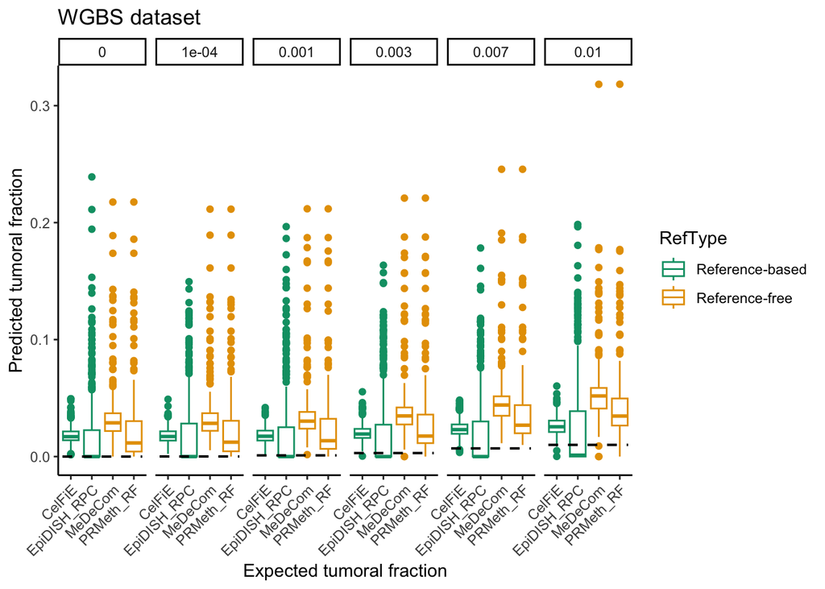

```r
# Subset to low fractions (<=0.01) samples
plot_data_lf <- in_silico_wgbs %>%
  filter(deconv_tool %in% c("CelFiE",
                            "EpiDISH_RPC",
                            "MeDeCom",
                            "PRMeth_RF") &
         expected_tf <= 0.01) %>%
  mutate(RefType = ifelse(deconv_tool %in% c("PRMeth_RF","MeDeCom"),
                          "Reference-free", "Reference-based"))

# Create a df to store the expected tumor fraction values to later on plot them
lines_lf <- data.frame(
  expected_tf = unique(plot_data_lf$expected_tf),
  y = unique(plot_data_lf$expected_tf)
)


# Generate the boxplots
p <- plot_data_lf %>%
          group_by(deconv_tool) %>%
          ggplot(aes(x = deconv_tool, y = predicted_tf,  color = RefType)) +
          geom_boxplot() +
          facet_wrap(~ as.factor(expected_tf), ncol = 6) +
          geom_segment(
            data = lines_lf,
            aes(
              x = 0.6,
              xend = length(unique(plot_data_lf$deconv_tool)) + 0.4,
              y = y, yend = y,
              group = expected_tf
              ),
            inherit.aes = FALSE,
            color = "black", linetype = "dashed", size = 0.7) +
          labs(
            title = paste("WGBS dataset"),
            x = "Expected tumoral fraction",
            y = "Predicted tumoral fraction") +
          theme_classic() +
          theme(
            axis.text.x = element_text(angle = 45, hjust = 1)) +
          scale_color_manual(values = c(
            "Reference-based" = "#009E73",
            "Reference-free" = "#E69F00"))
p
```

```r
# Create the main directory to save the plots
output_dir <- paste0(dir_path, "plots/04_refree_vs_refbased/boxplots")
if (!dir.exists(output_dir)) dir.create(output_dir)

output_file <- file.path(output_dir, paste0("boxplot_predictions_wgbs_lf.png"))
ggsave(output_file, plot = p, width = 8, height = 6)
```

And now plot the high fractions mixtures

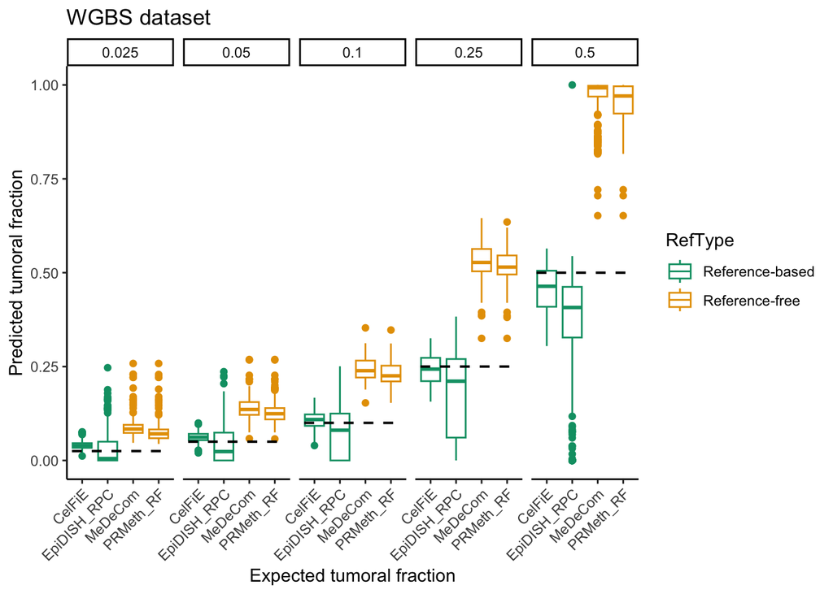

```r
# Subset to low fractions (<=0.01) samples
plot_data_hf <- in_silico_wgbs %>%
  filter(deconv_tool %in% c("CelFiE",
                            "EpiDISH_RPC",
                            "MeDeCom",
                            "PRMeth_RF") &
         expected_tf > 0.01) %>%
  mutate(RefType = ifelse(deconv_tool %in% c("PRMeth_RF","MeDeCom"),
                          "Reference-free", "Reference-based"))

# Create a df to store the expected tumor fraction values to later on plot them
lines_hf <- data.frame(
  expected_tf = unique(plot_data_hf$expected_tf),
  y = unique(plot_data_hf$expected_tf)
)


# Generate the boxplots
p <- plot_data_hf %>%
          group_by(deconv_tool) %>%
          ggplot(aes(x = deconv_tool, y = predicted_tf,  color = RefType)) +
          geom_boxplot() +
          facet_wrap(~ as.factor(expected_tf), ncol = 6) +
          geom_segment(
            data = lines_hf,
            aes(
              x = 0.6,
              xend = length(unique(plot_data_hf$deconv_tool)) + 0.4,
              y = y, yend = y,
              group = expected_tf
              ),
            inherit.aes = FALSE,
            color = "black", linetype = "dashed", size = 0.7) +
          labs(
            title = paste("WGBS dataset"),
            x = "Expected tumoral fraction",
            y = "Predicted tumoral fraction") +
          theme_classic() +
          theme(
            axis.text.x = element_text(angle = 45, hjust = 1)) +
          scale_color_manual(values = c(
            "Reference-based" = "#009E73",
            "Reference-free" = "#E69F00"))
p
```

```r
# Create the main directory to save the plots
output_dir <- paste0(dir_path, "plots/04_refree_vs_refbased/boxplots")
if (!dir.exists(output_dir)) dir.create(output_dir)

output_file <- file.path(output_dir, paste0("boxplot_predictions_wgbs_hf.png"))
ggsave(output_file, plot = p, width = 8, height = 6)
```

## RRBS - ref-based vs ref-free

Let’s now generated the results for the RRBS datasets as well, in the same way we did previously.

```r
# Compute the RMSE and add a column specifying whether the tool is ref-free or ref-based
rmse_rrbs <- in_silico_rrbs %>%
  filter(expected_tf != 0) %>%
  group_by(deconv_tool, dmr_tool, seq_depth, tumor_type, expected_tf) %>%
  mutate(RMSE = rmse(expected_tf, predicted_tf)) %>%
  ungroup() %>%
  group_by(seq_depth, tumor_type, expected_tf) %>%
  mutate(
    RMSE_min = min(RMSE),
    RMSE_max = max(RMSE),
    RMSE_minmax = (RMSE - RMSE_min) / (RMSE_max - RMSE_min)
  ) %>%
  group_by(deconv_tool, seq_depth, tumor_type) %>%
  summarise(RMSE = 1-mean(RMSE_minmax), .groups = "drop") %>%
  mutate(RefType = ifelse(deconv_tool %in% c("PRMeth_RF","MeDeCom"), "Reference-free", "Reference-based"))
```

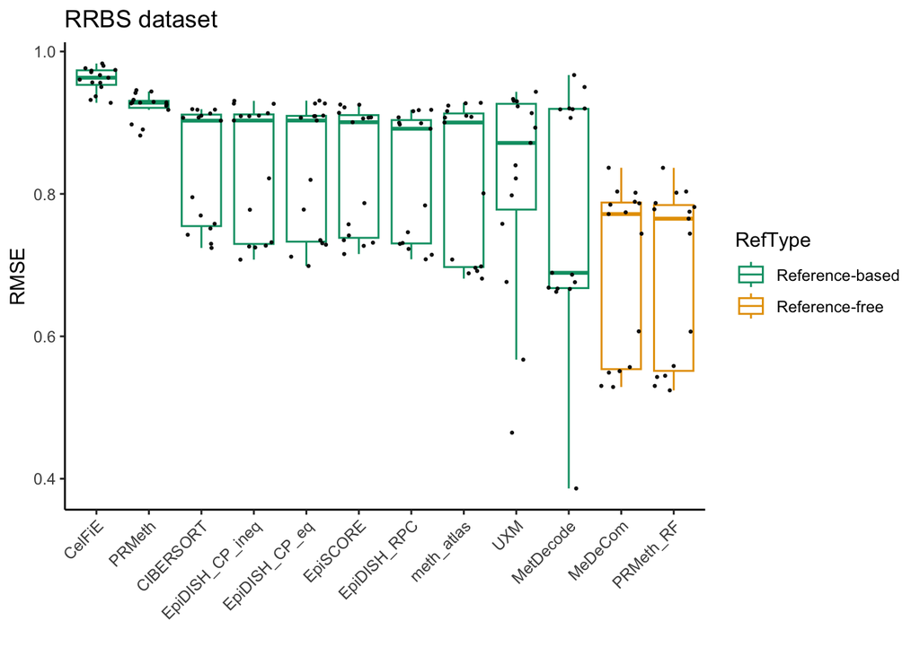

```r
# Rank the tools by mean RMSE
mean_rank <- rmse_rrbs %>%
              group_by(deconv_tool) %>%
              summarise(Mean = mean(RMSE)) %>%
              arrange(desc(Mean))
plot_data <- rmse_rrbs %>%
      mutate(deconv_tool = factor(deconv_tool, levels = mean_rank$deconv_tool))

# Plot the data
p <- plot_data %>%
        ggplot(aes(x = deconv_tool, y = RMSE, color = RefType)) +
        geom_boxplot(alpha = 0.8, outliers = F) +
        geom_jitter(color="black", size=0.4, alpha=0.9) +
        labs(
          title = "RRBS dataset",
          x = "",
          y = "RMSE"
        ) +
        theme_classic() +
        theme(
          axis.text.x = element_text(angle = 45, hjust = 1)
        ) +
        scale_color_manual(values = c(
          "Reference-based" = "#009E73",
          "Reference-free" = "#E69F00"
        ))
p
```

```r
# Create the main directory to save the plots
output_dir <- paste0(dir_path, "plots/04_refree_vs_refbased")
if (!dir.exists(output_dir)) dir.create(output_dir)

ggsave(paste0(output_dir, "/rmse_rrbs.png"), p, width = 8, height = 6)
```

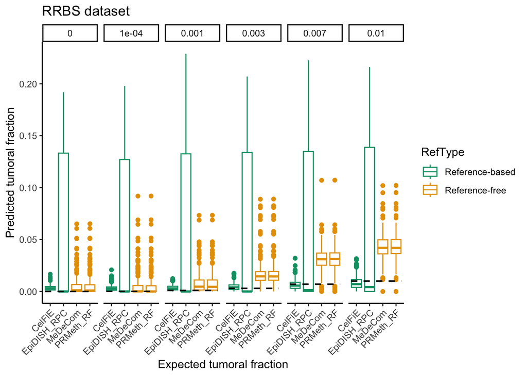

```r
# Subset to low fractions (<=0.01) samples
plot_data_lf <- in_silico_rrbs %>%
  filter(deconv_tool %in% c("CelFiE",
                            "EpiDISH_RPC",
                            "MeDeCom",
                            "PRMeth_RF") &
         expected_tf <= 0.01) %>%
  mutate(RefType = ifelse(deconv_tool %in% c("PRMeth_RF","MeDeCom"),
                          "Reference-free", "Reference-based"))

# Create a df to store the expected tumor fraction values to later on plot them
lines_lf <- data.frame(
  expected_tf = unique(plot_data_lf$expected_tf),
  y = unique(plot_data_lf$expected_tf)
)


# Generate the boxplots
p <- plot_data_lf %>%
          group_by(deconv_tool) %>%
          ggplot(aes(x = deconv_tool, y = predicted_tf,  color = RefType)) +
          geom_boxplot() +
          facet_wrap(~ as.factor(expected_tf), ncol = 6) +
          geom_segment(
            data = lines_lf,
            aes(
              x = 0.6,
              xend = length(unique(plot_data_lf$deconv_tool)) + 0.4,
              y = y, yend = y,
              group = expected_tf
              ),
            inherit.aes = FALSE,
            color = "black", linetype = "dashed", size = 0.7) +
          labs(
            title = paste("RRBS dataset"),
            x = "Expected tumoral fraction",
            y = "Predicted tumoral fraction") +
          theme_classic() +
          theme(
            axis.text.x = element_text(angle = 45, hjust = 1)) +
          scale_color_manual(values = c(
            "Reference-based" = "#009E73",
            "Reference-free" = "#E69F00"))
p
```

```r
# Create the main directory to save the plots
output_dir <- paste0(dir_path, "plots/04_refree_vs_refbased/boxplots")
if (!dir.exists(output_dir)) dir.create(output_dir)

output_file <- file.path(output_dir, paste0("boxplot_predictions_rrbs_lf.png"))
ggsave(output_file, plot = p, width = 8, height = 6)
```

And now plot the high fractions mixtures

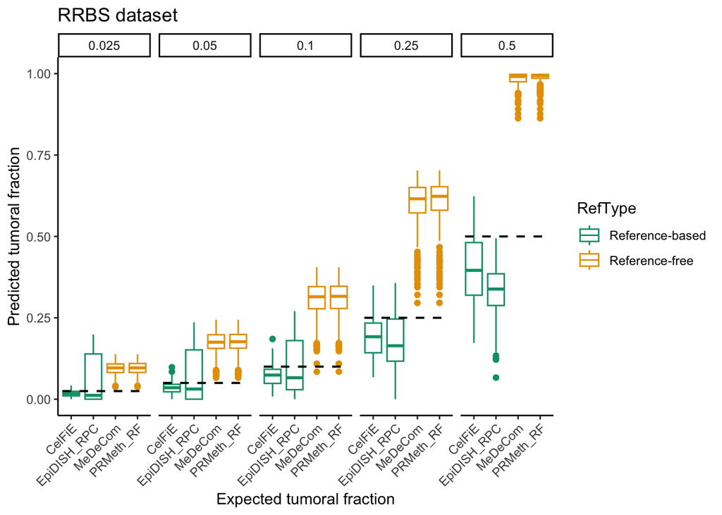

```r
# Subset to low fractions (<=0.01) samples
plot_data_hf <- in_silico_rrbs %>%
  filter(deconv_tool %in% c("CelFiE",
                            "EpiDISH_RPC",
                            "MeDeCom",
                            "PRMeth_RF") &
         expected_tf > 0.01) %>%
  mutate(RefType = ifelse(deconv_tool %in% c("PRMeth_RF","MeDeCom"),
                          "Reference-free", "Reference-based"))

# Create a df to store the expected tumor fraction values to later on plot them
lines_hf <- data.frame(
  expected_tf = unique(plot_data_hf$expected_tf),
  y = unique(plot_data_hf$expected_tf)
)


# Generate the boxplots
p <- plot_data_hf %>%
          group_by(deconv_tool) %>%
          ggplot(aes(x = deconv_tool, y = predicted_tf,  color = RefType)) +
          geom_boxplot() +
          facet_wrap(~ as.factor(expected_tf), ncol = 6) +
          geom_segment(
            data = lines_hf,
            aes(
              x = 0.6,
              xend = length(unique(plot_data_hf$deconv_tool)) + 0.4,
              y = y, yend = y,
              group = expected_tf
              ),
            inherit.aes = FALSE,
            color = "black", linetype = "dashed", size = 0.7) +
          labs(
            title = paste("RRBS dataset"),
            x = "Expected tumoral fraction",
            y = "Predicted tumoral fraction") +
          theme_classic() +
          theme(
            axis.text.x = element_text(angle = 45, hjust = 1)) +
          scale_color_manual(values = c(
            "Reference-based" = "#009E73",
            "Reference-free" = "#E69F00"))
p
```

```r
# Create the main directory to save the plots
output_dir <- paste0(dir_path, "plots/04_refree_vs_refbased/boxplots")
if (!dir.exists(output_dir)) dir.create(output_dir)

output_file <- file.path(output_dir, paste0("boxplot_predictions_rrbs_hf.png"))
ggsave(output_file, plot = p, width = 8, height = 6)
```